# Regression Analysis 2

- Show All Code
- Hide All Code
- View Source

Author

Alexis Alberto Zúñiga Alonso

Published

October 2, 2026

## 1. Introduction

### 1.1. Project Libraries and Installation

```r
# Project libraries
libs <- c("tidyverse", "readxl", "knitr")

# Install only the missing ones
missing <- setdiff(libs, rownames(installed.packages()))
if (length(missing) > 0) {
  install.packages(missing, repos = "https://cloud.r-project.org")
}

# Load all of them
invisible(lapply(libs, library, character.only = TRUE))
```

## 2. Problem 2: Seed Germination (Logistic Regression)

In a study on seed germination, two seed types and two rootstock types were used. The goal is to determine whether the rootstock and the seed type determine whether a plant germinates. The results are in `germ.xlsx`.

### 2.1. Initial Description of the Data

```r
germ_raw <- read_excel("data/germ.xlsx")
str(germ_raw)
```

```
tibble [831 × 3] (S3: tbl_df/tbl/data.frame)
 $ Portain  : chr [1:831] "Bean" "Bean" "Bean" "Bean" ...
 $ Semilla  : chr [1:831] "OA75" "OA75" "OA75" "OA75" ...
 $ Resultado: chr [1:831] "Germ" "Germ" "Germ" "Germ" ...
```

```r
colSums(is.na(germ_raw))
```

```
  Portain   Semilla Resultado
        0         0         0
```

The dataset has 831 observations (one per seed) and no missing values. All three variables are categorical:

- `Portain` (rootstock): `Bean` or `Cucumber`.
- `Semilla` (seed type): `OA73` or `OA75`.
- `Resultado` (result): `Germ` (germinated) or `NotGerm` (did not germinate). This is the **response variable**.

For the model, the response is coded as `1` = germinated and `0` = did not germinate, and the explanatory variables are converted to factors. The reference levels are `Bean` and `OA73` (alphabetical order).

```r
germ <- germ_raw |>
  mutate(
    germinated = if_else(Resultado == "Germ", 1, 0),
    Portain    = factor(Portain),
    Semilla    = factor(Semilla)
  )
```

#### 2.1.1. Frequency Tables

```r
germ |> count(Portain) |> kable(caption = "Seeds per rootstock")
```

Seeds per rootstock

| Portain | n |
| --- | --- |
| Bean | 395 |
| Cucumber | 436 |

```r
germ |> count(Semilla) |> kable(caption = "Seeds per seed type")
```

Seeds per seed type

| Semilla | n |
| --- | --- |
| OA73 | 264 |
| OA75 | 567 |

```r
germ |> count(Resultado) |> kable(caption = "Germination result")
```

Germination result

| Resultado | n |
| --- | --- |
| Germ | 424 |
| NotGerm | 407 |

#### 2.1.2. Germination Proportion by Group

```r
germ_summary <- germ |>
  group_by(Portain, Semilla) |>
  summarise(
    n            = n(),
    n_germinated = sum(germinated),
    proportion   = mean(germinated),
    .groups = "drop"
  )

germ_summary |> kable(digits = 3, caption = "Germination by rootstock and seed")
```

Germination by rootstock and seed

| Portain | Semilla | n | n_germinated | proportion |
| --- | --- | --- | --- | --- |
| Bean | OA73 | 123 | 49 | 0.398 |
| Bean | OA75 | 272 | 99 | 0.364 |
| Cucumber | OA73 | 141 | 75 | 0.532 |
| Cucumber | OA75 | 295 | 201 | 0.681 |

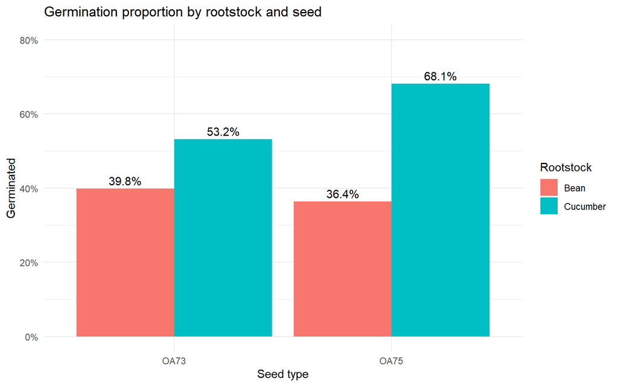

```r
germ_summary |>
  ggplot(aes(x = Semilla, y = proportion, fill = Portain)) +
  geom_col(position = "dodge") +
  geom_text(aes(label = scales::percent(proportion, accuracy = 0.1)),
            position = position_dodge(width = 0.9), vjust = -0.4) +
  scale_y_continuous(labels = scales::percent, limits = c(0, 0.8)) +
  labs(title = "Germination proportion by rootstock and seed",
       x = "Seed type", y = "Germinated", fill = "Rootstock") +
  theme_minimal()
```

**Observations:**

- Seeds on the `Cucumber` rootstock germinate more often than those on `Bean`, for both seed types.
- The effect of the seed type depends on the rootstock: with `Bean`, `OA75` germinates slightly *less* than `OA73`; with `Cucumber`, `OA75` germinates clearly *more*. This suggests an **interaction** between rootstock and seed, which is tested in the model.

### 2.2. Logistic Regression Model

#### 2.2.1. Main Effects Model

$$\log\left(\frac{p}{1-p}\right) = \beta_0 + \beta_1\,\text{Cucumber} + \beta_2\,\text{OA75}$$

```r
logit_main <- glm(germinated ~ Portain + Semilla, family = binomial, data = germ)
summary(logit_main)
```

```
Call:
glm(formula = germinated ~ Portain + Semilla, family = binomial,
    data = germ)

Coefficients:
                Estimate Std. Error z value Pr(>|z|)
(Intercept)      -0.7005     0.1507  -4.648 3.36e-06 ***
PortainCucumber   1.0647     0.1442   7.383 1.55e-13 ***
SemillaOA75       0.2705     0.1547   1.748   0.0804 .
---
Signif. codes:  0 '***' 0.001 '**' 0.01 '*' 0.05 '.' 0.1 ' ' 1

(Dispersion parameter for binomial family taken to be 1)

    Null deviance: 1151.7  on 830  degrees of freedom
Residual deviance: 1092.6  on 828  degrees of freedom
AIC: 1098.6

Number of Fisher Scoring iterations: 4
```

#### 2.2.2. Model with Interaction

$$\log\left(\frac{p}{1-p}\right) = \beta_0 + \beta_1\,\text{Cucumber} + \beta_2\,\text{OA75} + \beta_3\,(\text{Cucumber} \times \text{OA75})$$

```r
logit_int <- glm(germinated ~ Portain * Semilla, family = binomial, data = germ)
summary(logit_int)
```

```
Call:
glm(formula = germinated ~ Portain * Semilla, family = binomial,
    data = germ)

Coefficients:
                            Estimate Std. Error z value Pr(>|z|)
(Intercept)                  -0.4122     0.1842  -2.238   0.0252 *
PortainCucumber               0.5401     0.2498   2.162   0.0306 *
SemillaOA75                  -0.1459     0.2232  -0.654   0.5132
PortainCucumber:SemillaOA75   0.7781     0.3064   2.539   0.0111 *
---
Signif. codes:  0 '***' 0.001 '**' 0.01 '*' 0.05 '.' 0.1 ' ' 1

(Dispersion parameter for binomial family taken to be 1)

    Null deviance: 1151.7  on 830  degrees of freedom
Residual deviance: 1086.2  on 827  degrees of freedom
AIC: 1094.2

Number of Fisher Scoring iterations: 4
```

#### 2.2.3. Model Comparison (Likelihood Ratio Test)

- $H_0$: the interaction is not needed ($\beta_3 = 0$).
- $H_1$: the interaction is needed ($\beta_3 \neq 0$).

```r
anova(logit_main, logit_int, test = "Chisq")
```

```
Analysis of Deviance Table

Model 1: germinated ~ Portain + Semilla
Model 2: germinated ~ Portain * Semilla
  Resid. Df Resid. Dev Df Deviance Pr(>Chi)
1       828     1092.6
2       827     1086.2  1   6.4081  0.01136 *
---
Signif. codes:  0 '***' 0.001 '**' 0.01 '*' 0.05 '.' 0.1 ' ' 1
```

**Observations:** the p-value of the likelihood ratio test is less than 0.05, so $H_0$ is rejected: the interaction model fits significantly better, and it also has a lower AIC (1094.2 vs 1098.6). The interaction model is the one interpreted below.

### 2.3. Interpretation of the Coefficients

In logistic regression the coefficients are on the **log-odds** scale. Exponentiating them gives **odds ratios (OR)**, which are easier to interpret.

```r
odds_ratios <- exp(cbind(OR = coef(logit_int), confint.default(logit_int)))
odds_ratios |> kable(digits = 3, caption = "Odds ratios with 95% confidence intervals")
```

Odds ratios with 95% confidence intervals

|  | OR | 2.5 % | 97.5 % |
| --- | --- | --- | --- |
| (Intercept) | 0.662 | 0.462 | 0.950 |
| PortainCucumber | 1.716 | 1.052 | 2.800 |
| SemillaOA75 | 0.864 | 0.558 | 1.338 |
| PortainCucumber:SemillaOA75 | 2.177 | 1.194 | 3.970 |

```r
b <- coef(logit_int)
```

- **Intercept ($\beta_0$ = -0.4122):** for the reference group (`Bean` + `OA73`), the odds of germinating are $e^{\beta_0}$ = 0.662. That is, a germination probability of 0.398.
- **PortainCucumber ($\beta_1$ = 0.5401, p < 0.05):** with seed `OA73`, using the `Cucumber` rootstock multiplies the odds of germinating by 1.716 compared with `Bean` (a 71.6% increase).
- **SemillaOA75 ($\beta_2$ = -0.1459, p > 0.05):** with the `Bean` rootstock, seed `OA75` has odds of germinating 0.864 times those of `OA73`. This effect is **not significant**: on `Bean`, the seed type does not change germination.
- **Interaction ($\beta_3$ = 0.7781, p < 0.05):** the effect of the `Cucumber` rootstock is 2.177 times larger for seed `OA75` than for `OA73`. Combining the coefficients:
  - With `OA75`, `Cucumber` vs `Bean`: OR = $e^{\beta_1 + \beta_3}$ = 3.737.
  - With `Cucumber`, `OA75` vs `OA73`: OR = $e^{\beta_2 + \beta_3}$ = 1.882.

#### 2.3.1. Predicted Probabilities

```r
germ_summary |>
  select(Portain, Semilla) |>
  mutate(predicted = predict(logit_int, newdata = pick(everything()), type = "response")) |>
  kable(digits = 3, caption = "Predicted germination probability")
```

Predicted germination probability

| Portain | Semilla | predicted |
| --- | --- | --- |
| Bean | OA73 | 0.398 |
| Bean | OA75 | 0.364 |
| Cucumber | OA73 | 0.532 |
| Cucumber | OA75 | 0.681 |

**Conclusion:** both the rootstock and the seed type determine germination, but not independently. The highest germination probability (0.681) is obtained with the combination `Cucumber` + `OA75`. On `Bean`, the seed type makes no significant difference.